# bever Package: User’s Guide

Yves Deville

2020-04-25

This document was created with **bever** **0.1.0** and **potomax** **0.1.7**. As is the case for the whole package, this vignette is to be considered as a DRAFT version that still needs, checking, renaming, …

# Introduction

## Goals

The package **bever** is devoted to Extreme-Value models considered from the Bayesian perspective. It depends on the **potomax** package which consider the same models from a frequentist perspective with emphasis on the Maximum-Likelihood (ML) approach. So the two perspectives can be compared by using the same data and by producing similar results such as the classical Return-Level plots. So **bever** aims at producing these graphics and diagnostics. Although the package contains some functions dedicated to the estimation and inference of these Bayesian models, the results can also be produced by using Markov Chain Monte-Carlo with different R packages or even by using a sampling engine such as **JAGS** or **stan**. **bever** will then essentially retain the MCMC iterates.

## Extreme-Value Models

The package focuses on four types of Extreme-Value models, conveniently represented by an acronym (or abbreviated names) as follows.

1. `"GEV"` **GEV model** or Block Maxima. The parameters are: $\mu^\star$ (location), $\sigma^\star$ (scale) and $\xi^\star$ (shape). The blocks are assumed to have a constant known duration.
2. `"OS"` models for **$r$-largest order statistics** in blocks. The parameters are the GEV parameters $\mu^\star$, $\sigma^\star$, $\xi^\star$ as for block maxima, in reference with a constant block duration.
3. `"PP"` **Point-Process model** for Peaks Over Threshold (POT). The parameters are GEV parameters $\mu^\star$, $\sigma^\star$, $\xi^\star$ for a reference block duration. This model is fitted by using observations exceeding a given high threshold $u$. The parameters do not depend on $u$ and the support of the distribution includes values that are $<u$.
4. `"poisGP"` **Poisson-GP model** for POT. This model describes observations exceeding a given high threshold $u$. The parameters are: the rate $\lambda$ for the Poisson process of exceedances and the two parameters: $\sigma$ (scale) and $\xi$ (shape) for the Generalised Pareto (GP) distribution of the excesses over the given threshold.

In a first stage at least, the functions and methods are devoted in priority to the `"GEV"` and `"poisGP"` models.

The acronyms as used with the package will be case-insensitive, so `"pp"` and `"PP"` can be indifferently used for the Point-Process model of 3. So the model types are consistent with **revbayes**, although `"poisGP"` is not (yet) implemented in this package which uses instead the the binomial-GP model `"binGP"`.

Speaking of “models” as we did is somewhat abusive because the Point-Process or Poisson-GP models lead to the GEV block maxima model when they are aggregated in time, while the Block-Maxima or the Order Statistics models do not fully describe the extreme observations occurring within the blocks. These two later models do not provide a data generation process. We will consider the `"GEV"` and `"OS"` models as derived from a Poisson-GP process, either in its `"PP"` or in its `"poisGP"` parameterisation. Indeed, we could consider `"GEV"` and “`OS"` models as resulting form a temporal aggregation from a POT model as implemented in the `Renouv` function of **Renext**. As a major difference between `"PP"` and `"poisGP"`, the parameters of `"poisGP"` relate to the threshold $u$, while those of `"PP"` do not. Of course, while the `"PP"` parameter vector $[\mu^\star, \sigma^\star, \xi^\star]$ do not depend on the threshold $u$, its estimate $[\widehat{\mu}^\star, \widehat{\sigma}^\star, \widehat{\xi}^\star]$ does depend on $u$ which controls the censoring of the observations. However it is that the estimate remains quite stable when the threshold is high enough and when there remains enough data.

The models above will in this vignette be considered both from a frequentist and from a Bayesian perspective. In the second case, the inference will generally be based on Markov Chain Monte-Carlo (MCMC).

## Fitted models as S3 classes

### Classical “fitted model” objects

Following a vague terminology making sense at least for R users, we may call *fitted models* the results of estimation and inference for a specific couple *model* and *data*. The archetype would be the (fitted) linear model with the `"lm"` S3 class. A very common way to use a specific type of model in R consists in first creating an object by using the corresponding *constructor function*, to which the data are passed as formal argument(s). Then S3 methods such as `plot`, `summary`, `coef` are used. The name of constructor function is often chosen identical to the name of the S3 class: an object with class `"lm"` is created by using the `lm` function.

### “Poor Man’s” Posteriors

While these “gentleman’s rules” are retained in the package, we will in some cases allow the user to create fitted models objects by using results arising from other packages, as opposed to the usual fitting from data. For Bayesian fitted models, we will allow to create these from MCMC iterates as produced by other packages, possibly relying on sampling engines such as **JAGS** or **stan**. Doing so, the user is responsible for keeping track of the specific data that were used, these being no longer automatically duplicated into the fitted model object. However for each of the models defined above, there is a *minimal set of information* which must be given to allow the use of the model e.g. to derive predictions. Depending on the type of model, this involves: the *block duration*, the *observation duration* and possibly the *threshold*. The following table tells if an information is needed (Y) or not (N) depending on the type of object created.

| Model | Block duration | Obs. duration | Threshold |
| --- | --- | --- | --- |
| `GEV` | Yes | (# blocks) | No |
| `OS` | Yes | (# blocks) | No |
| `poisGP` | No | Yes | Yes |
| `PP` | Yes | Yes | Yes |

We can call an objects created from MCMC iterates *minimalist* or *poor man*’s posteriors. As shown later, they actually contain very little more than what can be guessed from the matrix given in `MCMC`.

While a fitted model should in principle embed a copy of all the information used for the fit - including the data, this assumption is likely to be over-demanding as far as we are interested in by-products such as graphics or diagnostics. So the creator functions for “poor man’s posteriors” will use several optional arguments.

The current version focuses on *only two EV models*: GEV and Poisson-GP, and provides the following objects

| Model | Bayes from data | Bayes from MCMC |
| --- | --- | --- |
| GEV |  | `GEVBayes0` |
| Poisson-GP | `poisGPBayes` | `poisGPBayes0` |

So the convention is (for now) that “from MCMC” objects have names ending by `0` to suggest an impoverishment relative to the classical object. Note for the GEV model only the “from MCMC” option is available.

### Illustration: GEV model for `portpirie`

Consider first fitting a GEV model for the `portpirie` data from **revdbayes**. We define a prior that can be used with the `"gev"` model

```r
priorGEV1 <- set_prior(prior = "flatflat", model = "gev")
postGEV1 <- rpost_rcpp(n = 10000, model = "gev", prior = priorGEV1, data = portpirie)
class(postGEV1)
```

```
## [1] "evpost"
```

```r
head(postGEV1$sim_vals, n = 3)
```

```
##            mu     sigma          xi
## [1,] 3.839869 0.2224023 -0.03932023
## [2,] 3.864992 0.1996913  0.15638303
## [3,] 3.829381 0.1765150  0.14745149
```

The MCMC iterates are stored in the `sim_vals` element of the posterior object. Using *this information only*, we can create a Poor Man’s Posterior.

```r
postGEV0 <- GEVBayes0(MCMC = postGEV1$sim_vals)
class(postGEV0)
```

```
## [1] "GEVBayes0" "Bayes0"
```

So the object `postGEV0` inherits from a class named `"Bayes0"` containing minimalist Bayesian objects. As its names suggests, the sub-class `GEVBayes0` is devoted to GEV models.

```r
summary(postGEV0)
```

```
## GEV Model Bayesian Inference
## o Block duration : 1
## o Number of blocks used: 0
## o Number of MCMC iterates: 10000
## o Posterior mean [sd]:
##            loc          scale          shape
##  3.874 [0.029]  0.207 [0.022] -0.034 [0.102]
```

```r
coef(postGEV0)
```

```
##             loc     scale       shape
## mean   3.874242 0.2066250 -0.03386356
## median 3.873725 0.2050267 -0.04145193
## mode         NA        NA          NA
```

```r
vcov(postGEV0)
```

```
##                 loc         scale         shape
## loc    0.0008209557  0.0002064182 -0.0009848911
## scale  0.0002064182  0.0004699084 -0.0007188484
## shape -0.0009848911 -0.0007188484  0.0103737911
```

Note that the parameters have been renamed: while **revdbayes** uses `mu`, `sigma` and `xi`, the corresponding parameters are now named: `loc`, `scale` and `shape` which better conforms to older EV packages. Note also that the block duration was by default considered as begin `1.0`.

The `coef` method can be used to extract estimates of the parameters. Several estimates can be computed from the `MCMC` matrix given: posterior mean, median of mode (MAP). The posterior mode was not displayed here nor computed because it is better to compute it by maximising the posterior function, but this function can not be retrieved from the MCMC iterates. The `GEVBayes0` function has a `MAP` formal argument that can be used to pass the MAP vector when available. This MAP will then be stored in the `GEVBayes0` object and it can later be used e.g. to build RL plots.

It should be noted that by using “MAP”, we generally name the *joint mode* and not the *vector of marginal modes*. By contrast, the median in `coef` is a vector of *marginal* medians, and not a multivariate median. For the mean there is no difference between *joint* an *marginal*.

$$\color{red}{\text{XXX Maybe change something in the package about Bayes
coef?}}$$

We could call an object such as `postGEV0` a *minimalist* or *poor man* s posterior. It actually contains very little more than what can be guessed from the matrix given in `MCMC`.

### Illustration: Poisson-GP model for the `rainfall` data

The creation of a Poor Man’s Posterior for a Poisson-GP model is a bit more tedious, mainly because this model is not very popular in the existing packages and especially not in **revdbayes** which favours the Binomial-GP model. Assuming that the rate $\lambda$ and the GP parameter $[\sigma,\, \xi]$ are a priori independent, these will remain a posteriori independent as long as ordinary data only are used.

We begin by retrieving the GP part of the posterior

```r
data(rainfall)
rainfall2 <- rainfall[!is.na(rainfall)]
u <- 40  ## threshold (mm)
w <- 57  ## obs duration (year)
nOT <- sum(rainfall2 > u)
nSim <- 10000
priorGP1 <- set_prior(prior = "flatflat", model = "gp")
postGP1 <- rpost_rcpp(n = nSim, model = "gp", prior = priorGP1,
                      data = rainfall2, thresh = u)
class(postGP1)
```

```
## [1] "evpost"
```

```r
head(postGP1$sim_vals, n = 3)
```

```
##       sigma[u]           xi
## [1,] 10.152676 -0.001455079
## [2,]  8.426331  0.143217149
## [3,]  7.177841  0.385533601
```

To get MCMC iterates for the rate $\lambda$ of the Poisson process of exceedances, we simply assume that a conjugate gamma prior is used, resulting in a gamma posterior from which we can easily simulate.

```r
MCMCpoisGP <- cbind(lambda = rgamma(nSim, shape = 1 + nOT, rate = 0 + w),
                    postGP1$sim_vals)
postGP0 <- poisGPBayes0(MCMC = MCMCpoisGP, threshold = u, effDuration = w)
summary(postGP0)
```

```
## poisGP Model Bayesian Inference
## o Number of OT observations: NA
## o Number of MCMC iterates: 10000
## o Posterior mean [sd]:
##      lambda       scale       shape
## 1.53 [0.16] 8.00 [1.29] 0.19 [0.13]
```

```r
coef(postGP0)
```

```
##          lambda    scale     shape
## mean   1.528050 8.002546 0.1941381
## median 1.520766 7.922622 0.1788894
## mode         NA       NA        NA
```

Since the difficult part of the posterior is the “GP” part, the `poisGPBayes0` function allows the use of a MCMC argument corresponding to a matrix with only two columns corresponding to the MCMC iterates for the GP parameter. In this case we have to provide the number of exceedances by using the `nOT` format argument, because this number is needed to determine the (gamma) posterior.

```r
postGP0b <- poisGPBayes0(MCMC = postGP1$sim_vals, threshold = u,
                         effDuration = w, nOT = nOT)
summary(postGP0b)
```

```
## poisGP Model Bayesian Inference
## o Number of OT observations: 86
## o Number of MCMC iterates: 10000
## o Posterior mean [sd]:
##      lambda       scale       shape
## 1.53 [0.16] 8.00 [1.29] 0.19 [0.13]
## 'lambda' and the GP parameter are a posteriori independent
```

```r
coef(postGP0b)
```

```
##          lambda    scale     shape
## mean   1.526316 8.002546 0.1941381
## median 1.520472 7.922622 0.1788894
## mode   1.508772       NA        NA
```

Note that the estimates for the GP part are *exactly* the same as before because they are based on the same MCMC iterates, while the estimate for the rate are slightly different because they no longer rely on MCMC iterates but rather on the *exact* marginal posterior for $\lambda$.

### Note on Poor Man’s Posteriors `*Bayes0`

Remind that the parameters of the EV models considered in **bever** relate to the GEV distribution, except for the Poisson-GP model for which $\sigma$ and $\xi$ are the scale and the shape parameter of the Generalised Pareto Distribution.

In this package, we use the convention that the parameters of the GPD and GEV distributions are named : `"loc"`, `"scale"` and `"shape"`. This conforms to the rule used in **Renext** and in classical EV packages such as **evd**, **ismev** or **extRemes**. The rate of the Poisson process in the Poisson-GP model is named `"lambda"`. Again, this conforms to the rule used in **Renext**.

Since the **bever** package aims at “importing” MCMC iterates from other R packages or software tools, it strives to understand several naming rules. For instance the parameter names used by **revdbayes** will be automatically translated into the names retained above. We believe that this strategy is unlikely to result into a misinterpretation of the parameters: it seems unlikely that a GEV shape parameter could be named `"sigma"` or `"mu"`. In case of doubt, the user will have to rename the columns of her MCMC matrices.

**CAUTION** For now no extensive tests have been made to asses a possible change of the order of the parameters.

# Bayes frameworks: priors and posteriors

The models or parameterisations described above can be used in a Bayesian framework. Here are some details.

## Poisson-GP framework

For the Poisson-GP model, some priors can be regarded as favourable. We will consider the prior based on the two following assumptions

- The rate $\lambda$ and the GP parameter $[\sigma, \, \xi]$ are a priori independent.
- The rate is a priori Gamma with shape $a_0>0$ and rate $b_0 \geqslant 0$.

The case $b_0= 0$ corresponds to an improper prior $\pi(\lambda) \propto \lambda^{a_0-1}$ which can make sense at least for $0 < a_0 \leqslant 1$. The special case $a_0 = 1$ corresponds to constant prior density for $\lambda$ i.e. to an improper uniform distribution on the support $(0,\,\infty[$.

*Inasmuch only ordinary “OT” observations are used*, the posterior is characterised by the following two properties.

- The rate $\lambda$ and the GP parameter $\boldsymbol{\theta}_{\text{GP}} := [\sigma, \, \xi]$ are a posteriori independent.
- The rate is a priori Gamma with shape $a_n = a_0 +n$ and rate $b_n = b_0 + w$ where $n$ is the number of exceedances and $w$ is the duration of the observation period.

However it should be kept in mind that the assumptions on the prior are relative to the threshold $u$: if these assumptions hold for a threshold $u$, they no longer hold for a threshold $u' > u$. Since the threshold $u$ is generally not known and has to be chosen empirically, the assumptions on the prior should be regarded as a trick to reach some computing simplifications and not as a theoretically well-founded rule.

## Other frameworks

For the other frameworks `GEV`, `rLOS` and `PP` the priors are for the vector $[\mu^\star,\,\sigma^\star,\,\xi^\star]$ of GEV parameters in relation with a specific block duration $w_{\text{block}}$, usually taken as one year. Some specific priors are available in the **revdbayes** package.

# Return level plots

## Classical Return Level plots: frequentist or Bayesian

### Displayed elements

This plot uses a time period $T$ as abscissa and a quantile as ordinate. The shown elements can be as follows.

- A point estimate of the return level $\rho(T)$ for a running period $T$ can be displayed as a curve. In the frequentist framework, the *ML estimate* $\widehat{\rho}(T)$ will usually be shown. In the Bayesian framework, the *mode* (MAP), the *median* and the *mean* of the posterior distribution for $\rho(T)$ can be used.
- The uncertainty on the estimates are can be shown by using confidence intervals on $\rho(T)$ in the frequentist framework, or credible intervals on $\rho(T)$ in the Bayesian framework.
- Finally we can display the observations used in the fit as “sample” points. This involves the use of suitable *plotting positions*.

When using **bever**, this plot will be obtained by first calling the `RL` method, then the `autoplot` method on the result which was produced by `RL`. The `autoplot` method produces a ggplot graphics object that can be modified. The three graphical elements above described correspond to layers of the `ggplot` object.

### Illustration for Poisson-GP fitted models

Consider first a frequentist fit using Garonne data from **Renext**. Since we aim at profile-likelihood inference on the return levels rather than the delta method, we will use the `protomax::poisGP` function to fit a frequentist Poisson-GP model

```r
library(bever)
y <- Garonne$OTdata$Flow
u <- Garonne$OTinfo$threshold
w <- Garonne$OTinfo$effDuration
gfitML <- poisGP(data = y, threshold = u, effDuration = w)
class(gfitML)
```

```
## [1] "poisGP"
```

```r
coef(gfitML)
```

```
##       lambda        scale        shape
##    2.3230769 1241.4173797   -0.1362312
```

```r
confint(gfitML)
```

```
## , , 95%
##
##              L        U
## lambda   1.972    2.714
## scale  988.964 1538.694
## shape   -0.209    0.045
```

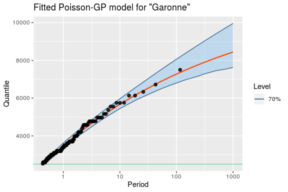

```r
autoplot(gfitML) +
    ggtitle("Fitted Poisson-GP model for \"Garonne\"") + theme_gray()
```

The `autoplot` S3 method produces a RL plot as a **ggplot2** graphics. The method used here is for the class `"poisGP"`. Note that it is easy to add or overwrite annotations, labels, …

The RL plot is similar to the one that would be obtained with **Renext** but the confidence intervals are here obtained by profile-likelihood and not by the delta method. These intervals are usually asymmetric, and the Upper bound is usually larger than that obtained by the delta method.

The `RL` method can be used to compute the return levels frm an object with class “`poisGP`”. This method then returns an object inheriting from the `"data.frame"` class which can again be used with `autoplot`.

```r
gRLML <- RL(gfitML, confintMethod = "proflik", trace = 0)
class(gRLML)
```

```
## [1] "RL.poisGP"  "data.frame"
```

```r
tail(gRLML, n = 6)
```

```
##    Period Level    Quant        L        U
## 15    200   70% 7665.279 7094.008 8654.835
## 16    250   70% 7783.468 7179.295 8841.814
## 17    300   70% 7877.404 7269.609 8993.197
## 18    500   70% 8128.498 7455.993 9410.771
## 19    700   70% 8284.596 7523.821 9680.573
## 20   1000   70% 8442.437 7626.501 9962.051
```

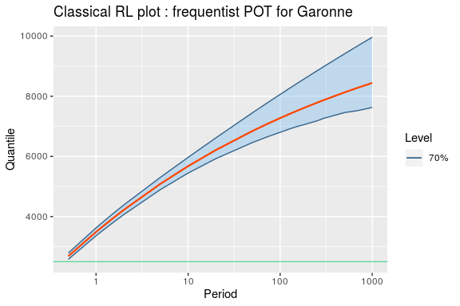

```r
autoplot(gRLML) +
    ggtitle("Classical RL plot : frequentist POT for Garonne") + theme_gray()
```

Now let use compare our frequentist results to those obtained with a Bayesian analysis of the same data

```r
gfitBayes <- poisGPBayes(data = y, threshold = u, effDuration = w)
class(gfitBayes)
```

```
## [1] "poisGPBayes"
```

```r
coef(gfitBayes)
```

```
##        lambda    scale      shape
## mode 2.323256 1239.904 -0.1356296
```

By default the Poisson parameter $\lambda$ and the GP parameter $[\sigma, \, \xi]$ are assumed a priori independent and both have a vague prior: the flat gamma prior for $\lambda$ and the `"flatflat"` prior of **revdbayes** is used for the GP parameter. The posterior mode is quite close to the ML estimate.

As for the `"poisGP"` class the `RL` method can be used for the Bayesian objects classes `"poisGPBayes"` and `"poisGPBayes0"`

```r
gRLBayes <- RL(gfitBayes, trace = 0)
class(gRLBayes)
```

```
## [1] "RL.poisGPBayes" "data.frame"
```

```r
tail(gRLBayes, n = 6)
```

```
##    Period Level     Mode   Median     Mean        L        U
## 13    200   70% 7667.248 7868.221 8091.693 6995.776 8502.123
## 14    250   70% 7785.736 7996.811 8241.650 7063.783 8661.381
## 15    300   70% 7879.921 8100.169 8362.380 7116.797 8789.940
## 16    500   70% 8131.734 8378.556 8692.551 7256.512 9144.850
## 17    700   70% 8288.320 8551.593 8903.951 7344.830 9376.772
## 18   1000   70% 8446.687 8726.088 9123.198 7436.566 9621.612
```

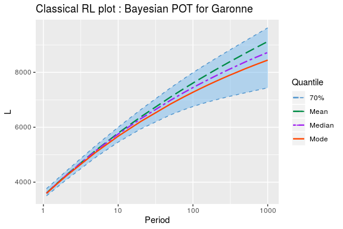

```r
autoplot(gRLBayes) +
    ggtitle("Classical RL plot : Bayesian POT for Garonne") + theme_gray()
```

Again the Bayesian RL plot is quite close to the frequentist one: the modal curve on the Bayesian RL is close to the quantile as estimated by ML, and the Bayesian credible intervals on quantiles are quite close to the profile-likelihood confidence interval for the same level (here $70\%$), although the limits of the Bayesian intervals are lower than those of the frequentist ones for large return periods. Of course, the Bayesian RL plot would be different if an informative prior had been specified.

Note that for the $x$-axis we use a scale which depends on the type of model. For a `GEV` model a Gumbel scale should be used because the theoretical RL curve corresponding to a Gumbel distribution will then show as a straight line. For POT models either `PP` or `poisGP` a logarithmic scale will be used because the theoretical RL curve corresponding to an exponential distribution will show as a straight line.

### Illustration for GEV models

We now compare the Bayesian and frequentist classical RL plots for a GEV model. Since the Bayesian GEV model. We use the `portpirie` data as provided by **revdbayes**: the observations are sea levels at Port Pirie (AU), in metres. The frequentist inference results and return levels are described in Chap. 3 of Coles’ book (Coles 2001).

We begin by fitting the data using ML. For that aim we can use the `poisGP` function of the **potomax** package which can provide the profile-likelihood confidence intervals on the return levels. Note that since we consider block maxima the `portpirie` data must be coerced into a list, and a vector of effective durations for the blocks must be provided.

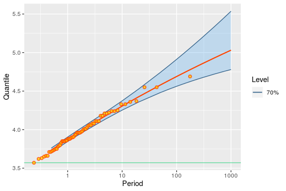

```r
fitp <- poisGP(MAX.data = as.list(portpirie),
               MAX.effDuration=rep(1, length(portpirie)))
autoplot(fitp) + theme_gray()
```

Since the Bayesian GEV model is available “on the shelf” in **revdbayes**, we will use this package, and then create a minimal posterior using `GEVBayes0` from **bever**. We reproduce here the three lines of code that were used before.

```r
prior <- set_prior(prior = "flatflat", model = "gev")
post <- rpost_rcpp(n = 10000, model = "gev", prior = prior, data = portpirie)
MAPp <- post$f_mode
names(MAPp) <- c("loc", "scale", "shape")
pfitGEV0 <- GEVBayes0(MCMC = post$sim_vals, yMax = portpirie, MAP = MAPp)
```

Note that the MAP must be given as a *named* vector with suitable names.

Then the RL plot is obtained as follows.

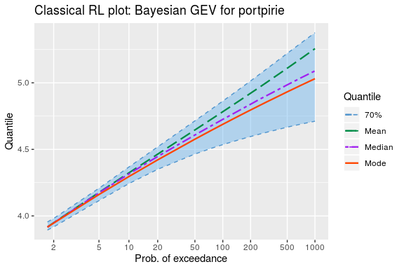

```r
myRL <- RL(pfitGEV0)
autoplot(myRL) + ggtitle("Classical RL plot: Bayesian GEV for portpirie") +
    theme_gray()
```

The plot can be compared to the one in Figure 3.5 in Coles’ book (Coles 2001).

It can be seen that the frequentist and Bayesian results are very close to each other. A quite subtle difference is that the Bayesian RL plot from **nexpot** uses a *Gumbel scale*, while that of **NSGEV** uses an *exponential scale*. The difference is mainly on the region corresponding to small return periods $T$, say for $T< 30$. Note that in order to display the “sample points”, we have to pass these when creating the `GEVBayes0` object, using the `yMax` argument. We could have created an object without giving `yMax` but it would the no longer have been possible to show the sample points. Similarly, we could have used the `MAP` formal argument, because the MAP is not computed by `GEVBayes0`.

## Predictive Return Level plot

### Displayed elements

The plot shows the predictive distribution of the maximum $Z^\star$ to be observed in a future or “new” period with given duration $w^\star$. More precisely, for some values of the exceedance probability $p$, we show the quantile $z^\star(p)$ of $Z^\star$ defined by $\text{Pr}\{Z^\star > z^\star(p)\} = p$. The duration $w^\star$ is usually chosen to be one year, but it could be the planned lifetime of an equipment.

An exceedance probability $p$ could be associated to the multiple $1/p$ of $w^\star$ hence to a period - e.g. $p=0.001$ relates to the period $1000\, w^\star$. However, in order to avoid confusions, **bever** will not use periods as tickmarks for the $x$-axis of the predictive RL plot.

It makes sense to display on a same plot the predictive quantile curves corresponding to several durations $w^\star_i$. Remind that by choosing a smaller the duration $w^\star$ we get “more conservative” quantiles, when these are compared for a same risk $p / w^\star$. For instance a “millennial risk” could be thought as defined by an exceedance probability $p_1 = 0.001$ and a duration $w_1^\star = 1$ year or by $p_2 = 0.01$ and $w_2^\star = 10$ year. In the later case we get a smaller quantile.

### Illustration: Poisson-GP POT for `Garonne` data

When using **bever**, this plot will be obtained by first calling the standard `predict` method, then the `autoplot` method on the result which was produced by `predict`. Again, the `autoplot` method produces a ggplot graphics object that can be modified.

```r
gpredBayes <- predict(gfitBayes)
```

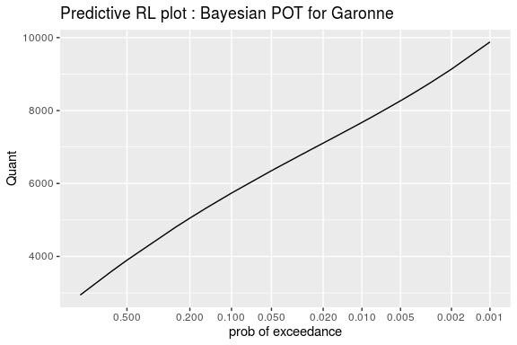

```r
autoplot(gpredBayes) +
    ggtitle("Predictive RL plot : Bayesian POT for Garonne") + theme_gray()
```

### Illustration: GEV model for `portpirie`

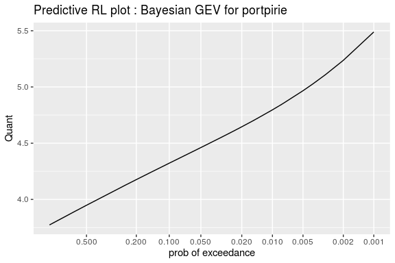

```r
ppredGEV0 <- predict(pfitGEV0)
autoplot(ppredGEV0) +
    ggtitle("Predictive RL plot : Bayesian GEV for portpirie") + theme_gray()
```

We can sometimes be interested in using MCMC inference results stored in matrix, ignoring the specific observations that were used. For instance we can be interested in a drawing a Return-Level plot (RL plot) from a fitted models, without caring for whether historical information was used or not. The base ingredient to create a PMP is *a matrix* say `MCMC` containing the MCMC iterates.

### Creating Poor Man’s Posteriors

- Except in very special cases where the posterior contains independent components, *the columns of `MCMC` should correspond to the parnames of the target model*.
- The *required information pieces* for the model should be given, see above.

For instance for a GEV model, the matrix `MCMC` must have three columns with suitable names; the block duration must be provided. The observation duration is not required but can be given. We can further give the observations which would allow display them on the RL plot.

# Relations to other packages

## revdbayes

The **revdbayes** package uses a single S3 class to represent posterior (or “fitted” versions) for several types of Bayesian EV models: `gev`, `os`, `pp`, `bingp` and more. This class is named `"evpost"`. As a difference with most classical R packages there is no eponymous creator function, and the objects of this class are created using either the `r_post` function or the faster-running `r_post_rcpp` function. Both these creator functions have many formal arguments because different types of models are allowed, depending on the value of the formal named `model`. An object of the class `"evpost"` is essentially a list. Since different kinds of models can be described, some “slots” or list elements can be `NULL`. For instance, the element `threshold` will be `NULL` when the model is `gev` or `os`.

# XXX Questions on **bever** design

- What should return the `coef` method?
- Choose the names of the data arguments to make available the ideas used in **Renext**. We can fit POT models using “OT” data, “Max” data and “OTS” data. All three should be optional arguments of the `poisGPML` creator, and possibly of its Bayesian companion `poisGPBayes`.

Coles, S. 2001. *An Introduction to Statistical Modelling of Extreme Values*. Springer.